# Weekly Option Data Integrity Test

2014-2018

Pritam Dalal

# Underlying: IWM

### Performance Analysis

| underlying | variation | hedging | total_pnl | sharpe | premium | prem_ret |
| --- | --- | --- | --- | --- | --- | --- |
| IWM | 0.1 | delta_hedge | 24 | 1.47 | 71.98 | 0.33 |
| IWM | 0.3 | delta_hedge | 21 | 0.64 | 280.87 | 0.07 |
| IWM | 0.5 | delta_hedge | 7 | 0.17 | 522.17 | 0.01 |
| IWM | 0.1 | naked | 18 | 0.68 | 71.98 | 0.24 |
| IWM | 0.3 | naked | 20 | 0.36 | 280.87 | 0.07 |
| IWM | 0.5 | naked | 14 | 0.23 | 522.17 | 0.03 |
| SPY | 0.1 | delta_hedge | 25 | 0.96 | 97.78 | 0.25 |
| SPY | 0.3 | delta_hedge | 22 | 0.49 | 368.16 | 0.06 |
| SPY | 0.5 | delta_hedge | 20 | 0.36 | 697.06 | 0.03 |
| SPY | 0.1 | naked | 12 | 0.27 | 97.78 | 0.12 |

[output cut: 2 more lines]

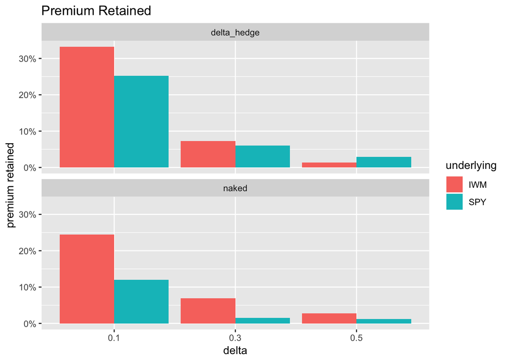

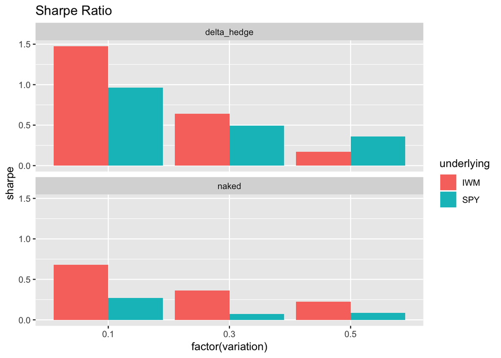

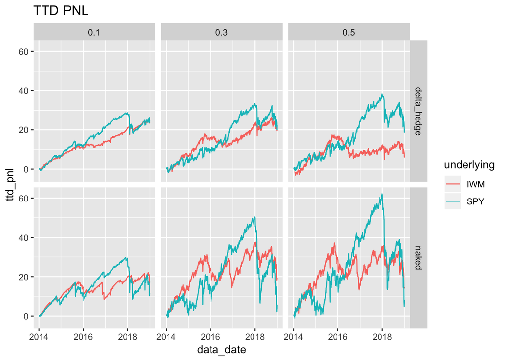

### Dates with Missing Data

These queries perform a crude check: *Are there any trade dates with completely missing data?*

If either of them returns rows, it could mean that there is something seriously wrong in the wrangling process.

#### **`df_chain_hist`**

```r
# df_chain_hist
df_td_all %>%
    left_join(
        df_chain_hist
        , by = "trade_date"
    ) %>%
    filter(is.na(underlying))
```

| trade_date | underlying | expiration | last_trade_date | implied_forward | bid_swap_rate | ask_swap_rate | mid_swap_rate |
| --- | --- | --- | --- | --- | --- | --- | --- |

#### **`df_opt_hist`**

```r
# df_opt_hist
df_td_all %>%
    left_join(
        df_opt_hist
        , by = c("trade_date" = "data_date")
    ) %>%
    filter(is.na(underlying_symbol))
```

| trade_date | underlying_symbol | underlying_price | type | expiration | strike | bid | ask | mid | volume | open_interest | t1_open_interest | iv_mean | implied_vol | delta | vega | theta |
| --- | --- | --- | --- | --- | --- | --- | --- | --- | --- | --- | --- | --- | --- | --- | --- | --- |

### Underlying Price Differences

One of the major drivers of PNL in my backtests is the underlying prices. In particular, I used them directly to calculate the final payoff of the options. I check the `underlying_price` values in the Delta-Neutral data set against Yahoo prices by using the `tidyquant` package.

Currently, this tests for difference of greater than 0.25%, but of course this sensitivity could be changed.

```r
df_underlying_px %>%
    select(date, close) %>%
    left_join(
        df_opt_hist %>% select(data_date, underlying_price)
        , by = c("date" = "data_date")
    ) %>%
    filter(abs((close - underlying_price) / close) > 0.0025) %>%
    group_by(date) %>%
    summarize(
        close = mean(close)
        , underlying_price = mean(underlying_price)
    ) %>%
    mutate(
        diff = close - underlying_price
    )
```

| date | close | underlying_price | diff |
| --- | --- | --- | --- |

### Missing Option Histories

Each unique option should have `n + 1` rows in `df_opt_hist` where `n` is the `d2x` of the option on execution date. (Note: the reworking of the `missing_data()` function that I did on 2/28/2019 is what makes this hold in a strong way.)

```r
df_opt_hist %>%
    group_by(
        underlying_symbol, type, expiration, strike
    ) %>%
    summarize(
        row_count = n()
    ) %>%
    left_join(
        df_chain_desc %>% select(expiration, d2x)
        , by = "expiration"
    ) %>%
    filter(row_count != (d2x + 1))
```

| underlying_symbol | type | expiration | strike | row_count | d2x |
| --- | --- | --- | --- | --- | --- |

### Basic Checks on `df_chain_desc`

These are some basic checks on `df_chain_desc` that check for major problems with the wrangling process. They also check that the underlying is tradeable for each expriation.

```r
# 1) make sure there are no chains with less than four days to expiration
df_chain_desc %>%
    filter(d2x < 4)
```

| underlying | monthly | expiration | last_trade_date | execution | d2x | num_opts | exec_day_volume | realized_vol | ret |
| --- | --- | --- | --- | --- | --- | --- | --- | --- | --- |

```r
# 2) make sure there are at least 6 options per chain (tradeability)
df_chain_desc %>%
    filter(num_opts < 6)
```

| underlying | monthly | expiration | last_trade_date | execution | d2x | num_opts | exec_day_volume | realized_vol | ret |
| --- | --- | --- | --- | --- | --- | --- | --- | --- | --- |
| IWM | FALSE | 2017-03-31 | 2017-03-31 | 2017-03-24 | 5 | 5 | 114870 | 0.04813141 | 0.02198887 |

```r
# 3) make sure exec_day_volume is greater than 1000 (tradeability)
df_chain_desc %>%
    filter(exec_day_volume < 1000)
```

| underlying | monthly | expiration | last_trade_date | execution | d2x | num_opts | exec_day_volume | realized_vol | ret |
| --- | --- | --- | --- | --- | --- | --- | --- | --- | --- |

### Implied Volatilities vs Lagged Realized

In this section we investigate the implied volatilities as a way of checking if there are any majore issues with the price data.

##### Graphing Implied vs Realized

It is useful to plot `bid_swap_rate` and `realized_vol` over time to ensure that they move together. However, it’s hard to garner specific conclusions from this.

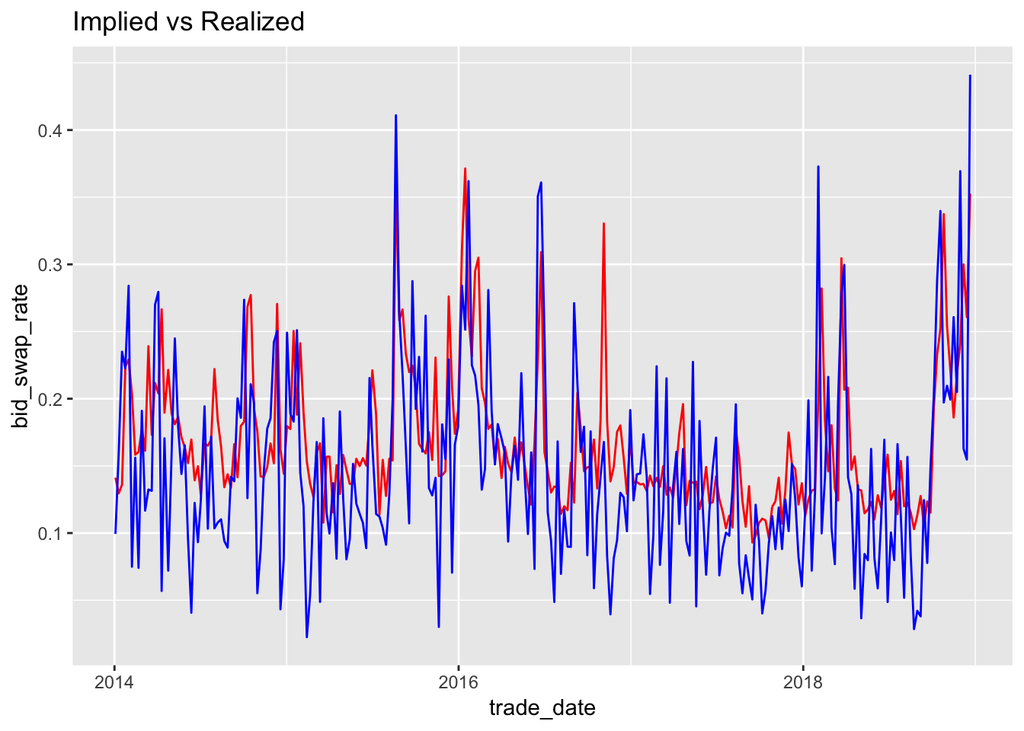

```r
df_chain_hist %>%
    left_join(
        df_chain_desc %>% select(expiration, execution, realized_vol)
        , by = "expiration"
    ) %>%
    filter(trade_date == execution) %>%
    ggplot() +
        geom_line(aes(x=trade_date, y=bid_swap_rate) , color="red") +
        geom_line(aes(x=trade_date, y=realized_vol), color="blue") +
        labs(
            title = "Implied vs Realized"
        )
```

##### Spike in Realized –> Spike in Implied

The next bit of analysis captures this essential feature of volatility markets: *a spike in realized volatility should lead to a spike in implied volatility*.

```r
## data set up ##

# lining up realized volatility and implied volatility by expiration
df_real_iv_comparison <-
    df_chain_hist %>%
    left_join( # to get execution date
        df_chain_desc %>%
            select(expiration, execution, realized_vol, ret)
        , by = "expiration"
    ) %>%
    filter(trade_date == execution) %>%
    select(
        expiration, execution, bid_swap_rate, realized_vol, ret
    ) %>%
    mutate(
        realized_change = realized_vol - lag(realized_vol)
        , iv_change = bid_swap_rate - lag(bid_swap_rate)
    )


# looking at the subsequent change in vol for each expiration
df_real_iv_comparison <-
    df_real_iv_comparison %>%
        mutate(
            subseq_iv_change = lead(iv_change)
        )
```

```r
#################################
## There Shouldn't Be Too Many ##
#################################
# (1) a sizeable jump in realized vol (> 5%)
# (2) the underlying experienced a loss during the expiration (< 0%)
# (3) a sizeable drop in implied vol (< -2%)
df_real_iv_comparison %>%
    filter(realized_change > 0.05) %>%
    filter(ret < 0) %>%
    filter(subseq_iv_change < -0.02)
```

| expiration | execution | bid_swap_rate | realized_vol | ret | realized_change | iv_change | subseq_iv_change |
| --- | --- | --- | --- | --- | --- | --- | --- |
| 2014-02-07 | 2014-01-31 | 0.2291724 | 0.2840726 | -0.012651209 | 0.06136544 | 0.005137669 | -0.02566150 |
| 2015-12-18 | 2015-12-11 | 0.2761031 | 0.2292657 | -0.003849683 | 0.07407724 | 0.130062295 | -0.06783979 |
| 2017-08-18 | 2017-08-11 | 0.1774185 | 0.1958123 | -0.011422743 | 0.06309230 | 0.073279435 | -0.02066210 |

### Implied Volatility vs CBOE Volatility Index

In the previous section we compared implieds to realized. Now we are comparing our implied to a volatility index. The CBOE publishes a variety of volatility indexes that will be useful to us.

```r
## data setup ##

# index comparison
df_index_comparison <-
    df_chain_hist %>%
        select(underlying, expiration, trade_date, mid_swap_rate) %>%
        left_join( # to get execution date
            df_chain_desc %>%
                select(expiration, execution, realized_vol, ret)
            , by = "expiration"
        ) %>%
        filter(trade_date == execution) %>%
        left_join( # to get vol-index value
            df_vol_index %>%
                mutate(vol_index = Close / 100) %>%
                select(Date, vol_index)
            , by = c("trade_date" = "Date")
        )


# calculating the difference between the bid swap rate and the vol_index
df_index_comparison <-
    df_index_comparison %>%
        mutate(vol_diff = mid_swap_rate - vol_index)
```

```r
#################################
## There Shouldn't Be Too Many ##
#################################
# (1) difference between vol-index and bid_swap_rate > 0.05
df_index_comparison %>%
    filter(abs(vol_diff) > 0.05) %>%
    arrange(vol_diff)
```

| underlying | expiration | trade_date | mid_swap_rate | execution | realized_vol | ret | vol_index | vol_diff |
| --- | --- | --- | --- | --- | --- | --- | --- | --- |
| IWM | 2016-06-10 | 2016-06-03 | 0.1232525 | 2016-06-03 | 0.1600145 | 0.0008619197 | 0.1742 | -0.05094749 |
| IWM | 2018-11-02 | 2018-10-26 | 0.3406405 | 2018-10-26 | 0.1971996 | 0.0432600769 | 0.2864 | 0.05424046 |
| IWM | 2018-03-29 | 2018-03-23 | 0.3124932 | 2018-03-23 | 0.2775031 | 0.0117928116 | 0.2532 | 0.05929319 |
| IWM | 2015-08-28 | 2015-08-21 | 0.3668173 | 2015-08-21 | 0.4109419 | 0.0050302739 | 0.2950 | 0.07181733 |
| IWM | 2016-11-11 | 2016-11-04 | 0.3342076 | 2016-11-04 | 0.1677936 | 0.0956714303 | 0.2538 | 0.08040760 |
| IWM | 2016-01-22 | 2016-01-15 | 0.3771095 | 2016-01-15 | 0.2513675 | 0.0124077709 | 0.2965 | 0.08060950 |

### Delta-Hedge PNLs vs Realized Volatility Premium

The delta-hedged strangle PNLs should be a function of the realized volatility premium. In this section, we check that this is the case.

Let’s begin look at a scatter plot of the vol-premium vs PNL ratio.

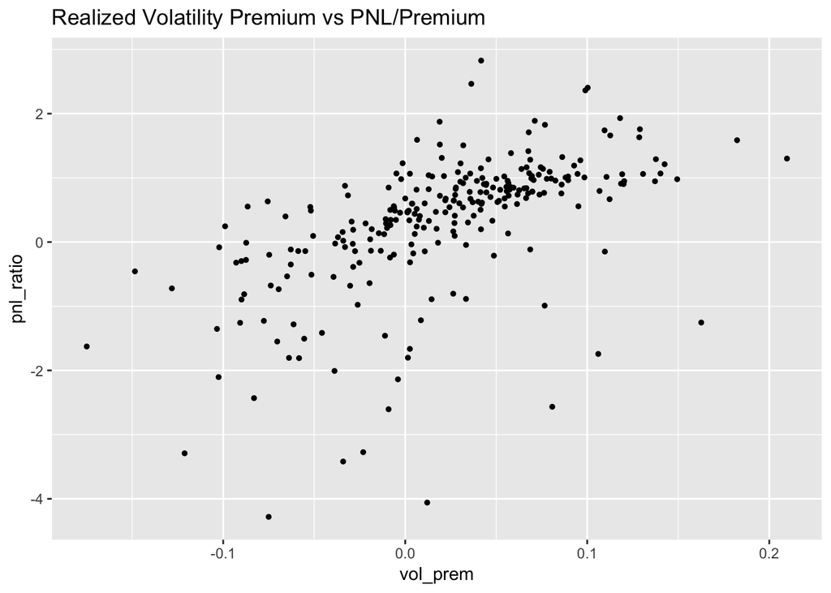

```r
# scatter plot of vol-premium vs PNL ratio
df_report %>%
    ggplot() +
    geom_point(aes(x = vol_prem, y = pnl_ratio), size=1) +
    labs(
        title = "Realized Volatility Premium vs PNL/Premium"
    )
```

#### PNLs Directionally Correct

Let’s count how many of the expiration PNLs were directionally correct. This should be a high percentage.

```r
df_report %>%
    filter(
        (vol_prem > 0 & pnl_ratio > 0) |
        (vol_prem < 0 & pnl_ratio < 0)
    )
```

| underlying_symbol | expiration | premium | pnl | realized_vol | bid_swap_rate | vol_prem | pnl_ratio |
| --- | --- | --- | --- | --- | --- | --- | --- |
| IWM | 2014-01-10 | 0.19 | 0.112935817 | 0.09936820 | 0.14121412 | 4.184592e-02 | 0.59439904 |
| IWM | 2014-01-18 | 0.20 | -0.136158406 | 0.15980992 | 0.12953462 | -3.027530e-02 | -0.68079204 |
| IWM | 2014-01-31 | 0.35 | 0.166896102 | 0.22270716 | 0.22403476 | 1.327607e-03 | 0.47684602 |
| IWM | 2014-02-07 | 0.33 | -0.046646325 | 0.28407260 | 0.22917243 | -5.490017e-02 | -0.14135250 |
| IWM | 2014-02-14 | 0.30 | 0.489579695 | 0.07493900 | 0.20351094 | 1.285719e-01 | 1.63193233 |
| IWM | 2014-02-22 | 0.20 | 0.067581230 | 0.15604238 | 0.15828718 | 2.244796e-03 | 0.33790614 |
| IWM | 2014-02-28 | 0.25 | 0.330955961 | 0.07410235 | 0.16036766 | 8.626531e-02 | 1.32382385 |
| IWM | 2014-03-07 | 0.24 | -0.032794146 | 0.19096869 | 0.17753684 | -1.343185e-02 | -0.13664228 |
| IWM | 2014-03-14 | 0.28 | 0.254150965 | 0.11670165 | 0.16125290 | 4.455125e-02 | 0.90768201 |
| IWM | 2014-03-22 | 0.37 | 0.294238648 | 0.13237759 | 0.23912481 | 1.067472e-01 | 0.79523958 |

[output cut: 196 more lines]

```
## [1] "Directionaly Correct Percentage: 0.79"
```

#### Should Be Winners

Let’s see how many should have been winners but actually turned out to be losers.

```r
# should have been winners but they were losers
df_report %>%
    filter(vol_prem > 0 & pnl_ratio < 0) %>%
    arrange(pnl_ratio)
```

| underlying_symbol | expiration | premium | pnl | realized_vol | bid_swap_rate | vol_prem | pnl_ratio |
| --- | --- | --- | --- | --- | --- | --- | --- |
| IWM | 2016-01-08 | 0.27 | -1.095775114 | 0.17936575 | 0.1914483 | 0.012082509 | -4.05842630 |
| IWM | 2016-12-09 | 0.29 | -0.744167060 | 0.09441963 | 0.1751923 | 0.080772617 | -2.56609332 |
| IWM | 2015-07-24 | 0.16 | -0.288318691 | 0.11222633 | 0.1136948 | 0.001468455 | -1.80199186 |
| IWM | 2018-12-21 | 0.48 | -0.836724713 | 0.15476576 | 0.2608214 | 0.106055686 | -1.74317647 |
| IWM | 2018-02-02 | 0.28 | -0.466078484 | 0.13007389 | 0.1326306 | 0.002556748 | -1.66456601 |
| IWM | 2016-11-11 | 0.49 | -0.614419782 | 0.16779362 | 0.3304201 | 0.162626437 | -1.25391794 |
| IWM | 2016-05-27 | 0.21 | -0.255909494 | 0.14245560 | 0.1510733 | 0.008617680 | -1.21861667 |
| IWM | 2018-03-09 | 0.37 | -0.366669230 | 0.10364787 | 0.1802650 | 0.076617083 | -0.99099791 |
| IWM | 2015-10-09 | 0.28 | -0.249580710 | 0.19243448 | 0.2069161 | 0.014481612 | -0.89135965 |
| IWM | 2017-04-28 | 0.36 | -0.319074724 | 0.16258453 | 0.1959680 | 0.033383417 | -0.88631868 |

[output cut: 10 more lines]

We explore the most egregious case and make sure the that we agree with the numbers.

```
## [1] 0.1793654
```

#### Should Be Losers

```r
# should have been losers but they were winners
df_report %>%
    filter(vol_prem < 0 & pnl_ratio > 0) %>%
    arrange(desc(pnl_ratio))
```

| underlying_symbol | expiration | premium | pnl | realized_vol | bid_swap_rate | vol_prem | pnl_ratio |
| --- | --- | --- | --- | --- | --- | --- | --- |
| IWM | 2014-06-06 | 0.23 | 0.282296110 | 0.1652900 | 0.1638571 | -0.001432862 | 1.22737437 |
| IWM | 2018-01-12 | 0.23 | 0.245555062 | 0.1174853 | 0.1126389 | -0.004846396 | 1.06763072 |
| IWM | 2014-08-01 | 0.25 | 0.245010017 | 0.1717625 | 0.1695362 | -0.002226239 | 0.98004010 |
| IWM | 2015-07-02 | 0.24 | 0.210208376 | 0.2153820 | 0.1823029 | -0.033079103 | 0.87586821 |
| IWM | 2018-10-12 | 0.40 | 0.339332243 | 0.2027764 | 0.1936573 | -0.009119142 | 0.84833063 |
| IWM | 2018-06-29 | 0.28 | 0.203363962 | 0.1694676 | 0.1380067 | -0.031460880 | 0.72629984 |
| IWM | 2014-04-11 | 0.34 | 0.215078593 | 0.2794802 | 0.2039388 | -0.075541420 | 0.63258409 |
| IWM | 2015-09-04 | 0.42 | 0.234353753 | 0.2645535 | 0.2582764 | -0.006277078 | 0.55798510 |
| IWM | 2017-03-24 | 0.22 | 0.121598174 | 0.2151745 | 0.1286059 | -0.086568584 | 0.55271898 |
| IWM | 2018-07-27 | 0.28 | 0.152950337 | 0.1662022 | 0.1140597 | -0.052142440 | 0.54625120 |

[output cut: 24 more lines]

We explore the most egregious case and make sure the that we agree with the numbers.

```
## [1] 0.1652918
```